# MPNeuronScratch

## MP Neuron Model

The McCulloch Pitts Model or the MP Neuron Model is the simplest of the Neural Networks built.  
The six jars of the model are :

- **Model** : y_pred = ( $\sum_{i=1}^n$ x_i >= $\theta$ ) where $\theta$ = Threshold for the model
- **Data** : The input to the MP Neuron model is binary and the output too is binary,i.e. X $\in$ {0,1} and y $\in$ {0,1}
- **Task** : Predict a Boolean output,i.e. Y_pred $\in$ {0,1} where 0 : the output is Negative and 1 : output is Positive.
- **Loss Function** : The loss function used is the squared error loss : $\sum_{i=1}^n (y\_pred - y)^2$. We could as well use the absolute error loss : $\sum_{i=1}^n |y\_pred - y|$ but absolute value function is not differentiable, hence, squared error loss is used.
- **Learning Algorithm** : The only parameter to learn is the threshold value $\theta$. The value can be learnt in two ways:
  - **Brute Force Method** : $\theta$ can have discrete values from 0 upto n, as $\sum_{i=1}^n$ x_i can take up value 0 when all x_i's are 0 and n when all x*i's are 1. So, we can check the loss function for all values of $\theta$ in range(0,n) and select the optimum $\theta*{opt}$ to be the one with minimum loss.
  - **Optimized Method** : Not discussed in the following code but can be implemented easily.
    1. Choose $\theta$ = `int(n/2)` and in each epoch do,
    2. Predict the output using the current value, and find Confusion Matrix
    3. `if false positive < false negative and` $\theta$ < n: `do` $\theta$ += 1  
       `else if false positive > false negative and` $\theta$ >= 1 : `do` $\theta$ -= 1  
       `else` $\theta$ remains unchanged`
- **Evaluation** : The evaluation metric is the accuracy score=$\frac{Number of Correct Predictions}{Total Number ofPredictions}$

```python
import numpy as np
import pandas as pd
import matplotlib.pyplot as plt
from sklearn.metrics import accuracy_score
from sklearn.metrics import mean_squared_error

plt.style.use("ggplot")
```

```python
class mpNeuron:
    def __init__(self,theta=0):
        self.theta = theta

    def predict(self,X):
        y_pred = [1 if sum(x)>=self.theta else 0 for x in np.asarray(X)]
        return y_pred

    def fit(self,X,y,):
        theta_values = [i for i in range(X.shape[1]+1)]
        accuracy = []
        loss = []
        for theta in theta_values:
            self.theta = theta
            y_pred = self.predict(X)
            accuracy.append(accuracy_score(y,y_pred))
            loss.append(mean_squared_error(y,y_pred)*X.shape[1])

        plt.figure(figsize=(20,8))
        plt.subplot(1,2,1)
        plt.scatter(theta_values,accuracy)
        opt_theta = accuracy.index(max(accuracy))
        max_accuracy = max(accuracy)
        plt.plot(opt_theta,max_accuracy,"bo")
        annot = "Best Fit\n"+"Theta :" + str(opt_theta) + "\nAccuracy :" \
        + str(round(max_accuracy,2))
        plt.annotate(annot,xy=(opt_theta,max_accuracy),xytext=(0,0.6),
                     arrowprops=dict(facecolor="gray",shrink=0.05))
        plt.title("Accuracy vs Threshold")
        plt.xlabel("Threshold value")
        plt.ylabel("Accuracy Score")
        self.theta = opt_theta
        plt.subplot(1,2,2)
        min_loss = loss[theta_values.index(opt_theta)]
        plt.scatter(theta_values,loss)
        plt.plot(opt_theta,min_loss,"bo")
        annot = "Best Fit\n"+"Theta :" + str(opt_theta) + "\nLoss :" \
        + str(min_loss)
        plt.annotate(annot,xy=(opt_theta,min_loss),xytext=(0,15),
                     arrowprops=dict(facecolor="gray",shrink=0.05))
        plt.title("Loss vs Threshold")
        plt.xlabel("Threshold value")
        plt.ylabel("Squared Error Loss")
```

```python
df = pd.read_csv("/home/soham/Documents/IIT Bombay/cse/2019 courses/deep learning/PadhAI/Deep Learning/mod 1 Python Basics/mobile_cleaned-1549119762886.csv")
df.head()
df.shape
```

```
(109, 40)
```

```python
df.shape
```

```
(109, 40)
```

```python
y = df["is_liked"]
X = df.drop(columns=["is_liked"])
```

```python
print("Mean for each column in the training Data.")
for i in X.columns:
    print(i,": ",X[i].median())
```

```
Mean for each column in the training Data.
sim_type :  0.0
aperture :  8.0
gpu_rank :  29.0
weight :  152.0
stand_by_time :  360.0
processor_frequency :  1.6
thickness :  8.1
flash_type :  5.0
front_camera_resolution :  5.0
auto_focus :  3.0
screen_size :  5.2
frames_per_second :  30.0
FM :  3.0
no_of_reviews_in_gsmarena_in_week :  24.0
os :  0.0
phone_height :  147.5
screen_protection :  16.0
sim_size :  5.0
price :  14614.0
talk_time :  19.0
video_resolution :  1080.0
display_resolution :  9.0
removable_battery :  1.0
display_type :  2.0
primary_camera_resolution :  13.0
battery_type :  2.0
ram_memory :  2.0
internal_memory :  2.0
brand_rank :  6.0
no_of_cores :  6.0
micro_sd_slot :  4.0
screen_pixel_density :  14.0
water_proof_rate :  6.0
phone_width :  73.7
expandable_memory :  32.0
version :  6.0
usb_type :  3.0
battery_capacity :  2900.0
processor_rank :  21.0
```

```python
thresholding = lambda x,y: 0 if x<y else 1
for col in X.columns:
    X[col] = X[col].apply(lambda x: 1 if x<X[col].median() else 0)
```

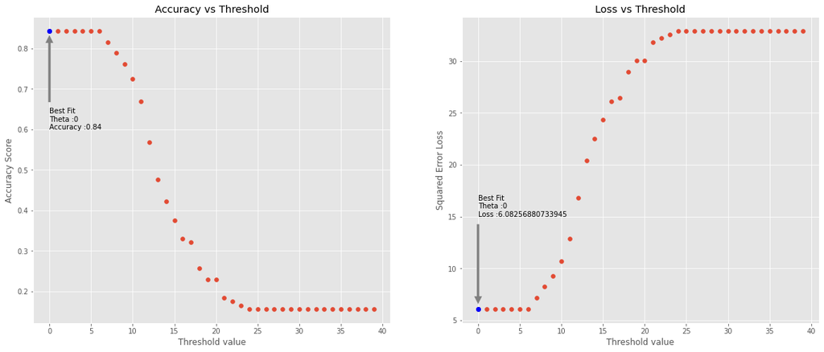

```python
model = mpNeuron()
model.fit(X,y)
```

```python
y_pred = model.predict(X)
accuracy = accuracy_score(y,y_pred)
print(accuracy)
```

```
0.8440366972477065
```